# Aides Drug

Erika Amado

30 October 2019

# Introduction

# Methods

In every one of these test we will be looking at the relationship between the categorical variables. We will be using a bar chart for graphical data, for numerical data we will be using cross tabulation and for inferential data we will be using a chi-squared test.

Question #1: Was the vaccine effective for the entire population?

$H_0$: The vaccine has no effect on whether the population contracts aids or not

$H_A$: The vaccine affects whether the population contracts aids or not

Question #2: Was the vaccine effective for gals?

$H_0$: The vaccine has no effect on whether gals contract aids or not

$H_A$: The vaccine affects whether gals contract aids or not

Question #3: Was the vaccine effective for guys?

$H_0$: The vaccine has no effect on whether guys contract aids or not

$H_A$: The vaccine affects whether guys contract aids or not

Question #4: Was the vaccine effective for drug users?

$H_0$: The vaccine has no effect on whether drug users contract aids or not

$H_A$: The vaccine affects whether drug users contract aids or not

Question 5: Was the vaccine for LGBTQ people?

$H_0$: The vaccine has no effect on whether LGBTQ people contract aids or not

$H_A$: The vaccine affects whether LGBTQ people contract aids or not

# Results

## Descriptive Results

### Graphical Descriptive Results

Question 1:

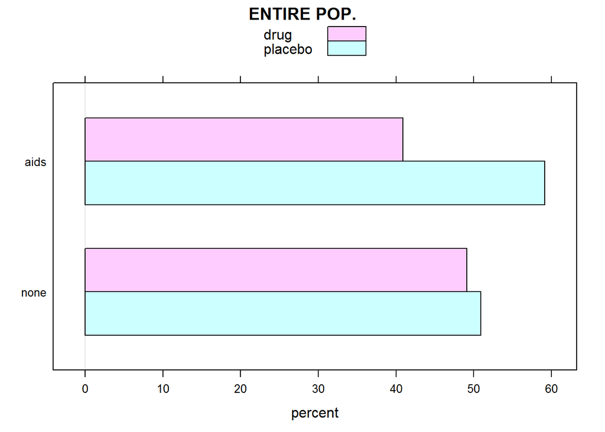

```r
barchartGC( ~ infected+treatment, type='percent', main= 'ENTIRE POP.', horizontal = TRUE, data=avast)
```

This barchart displays the entire population with aids and without aids is affected or not affected with the drug. The pink displays how much the drug prevented the aids virus as opposed to the placebo for people with aids. For people without aids the pink and blue are very close in range because they do not have the aids virus. If they were not close in range then that would mean something is wrong with this study.

Question 2:

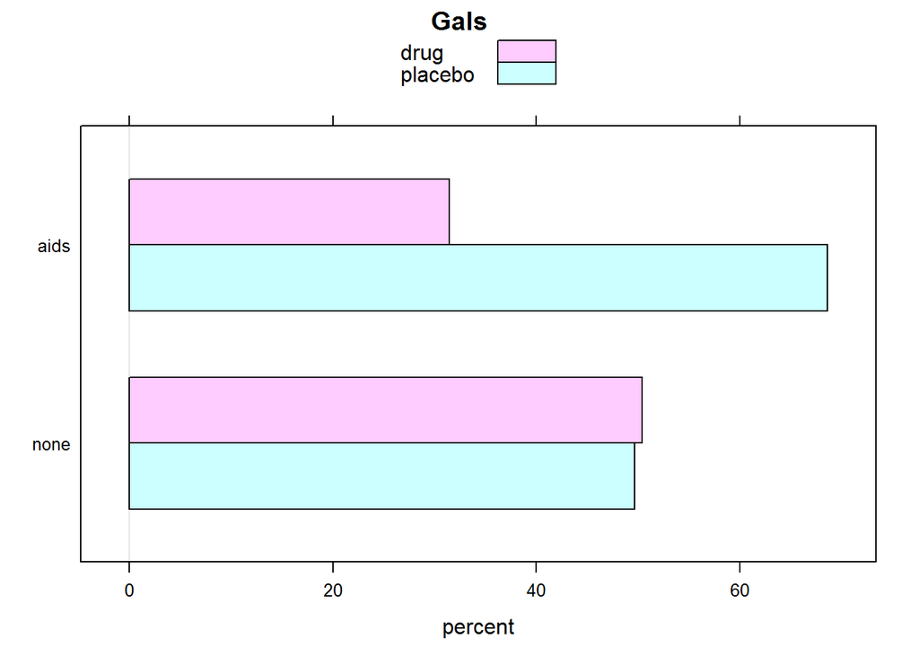

```r
barchartGC( ~infected+treatment, type='percent', main= 'Gals', data=filter(avast, sex=='gal'), horizontal = TRUE)
```

This barchart displays that the drug is effective for gals contracting AIDS.

Question 3:

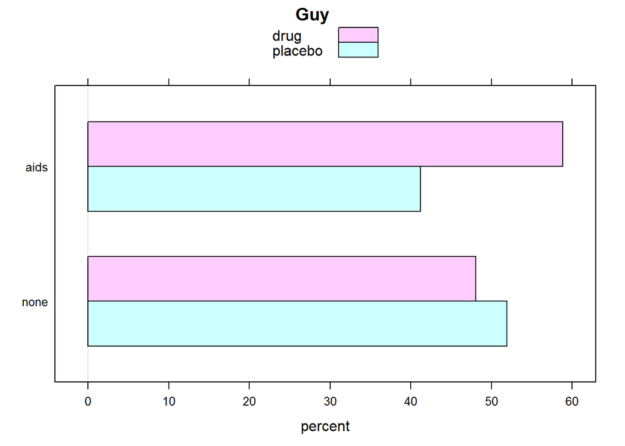

```r
barchartGC( ~infected+treatment, type='percent', main= 'Guy', data=filter(avast, sex=='guy'), horizontal = TRUE)
```

This barchart displays that guys with AIDS virus should not take the drug because it makes them more susceptible to getting aids.

Question 4:

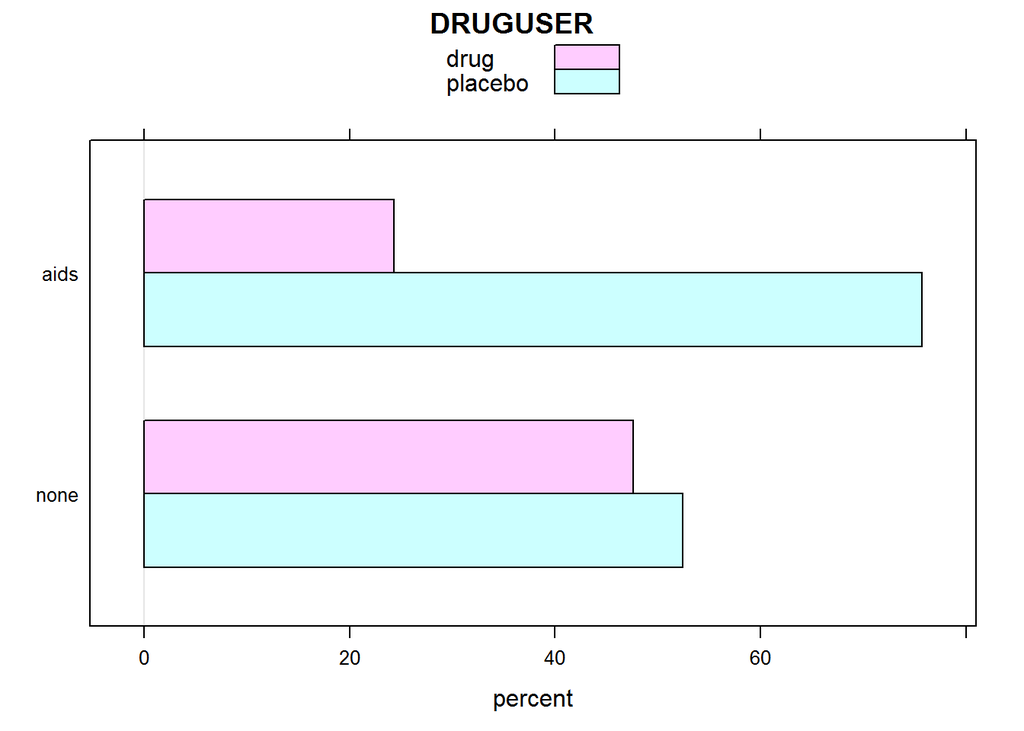

```r
barchartGC( ~infected+treatment, type='percent', horizontal = TRUE,main= 'DRUGUSER', data=filter(avast, DrugUser=='yes'))
```

This barchart displays people who are drug users and take the drug to prevent aids the results are far more effective than drug users who take the placebo. We can also see people who don’t have aids that use the placebo and the drug are close in range.

Question 5:

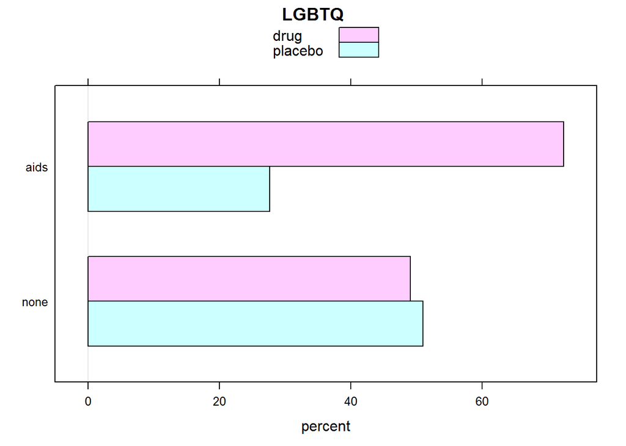

```r
barchartGC( ~infected+treatment, type='percent', horizontal = TRUE,main= 'LGBTQ', data=filter(avast, LGBTQ=='gay'))
```

This barchart displays people in the LGBTQ group who already have aids, should not take the drug because it made them more susceptible to getting aids.

### Numerical Descriptive Results

Question 1:

```r
tab = xtabs(~infected+treatment, data=filter(avast))
rowPerc(tab)
```

```
##         treatment
## infected   drug placebo  Total
##     aids  40.87   59.13 100.00
##     none  49.10   50.90 100.00
```

The table shows if a person has aids and uses the drug, the chances preventing the virus is high. The sample that uses the placebo has lower chance of preventing the virus. People who do not have aids that use the vaccine or placebo have very similar results.

Question 2:

```r
tab = xtabs(~infected+treatment, data=filter(avast, sex=='gal'))
rowPerc(tab)
```

```
##         treatment
## infected   drug placebo  Total
##     aids  31.42   68.58 100.00
##     none  50.38   49.62 100.00
```

The table shows if a gal who has aides has a higher chance on preventing the virus using the drug, oppposed to the sample that takes the placebo who have lower odds. People who do not have aids the difference is small.

Question 3:

```r
tab = xtabs(~infected+treatment, data=filter(avast, sex=='guy'))
rowPerc(tab)
```

```
##         treatment
## infected   drug placebo  Total
##     aids  58.82   41.18 100.00
##     none  48.06   51.94 100.00
```

The table shows that guys who have aids and take the drug are more likely to contract aids with the drug as opposed to the placebo they have better odds. People who do not have aids the difference is small.

Question 4:

```r
tab = xtabs(~infected+treatment, data=filter(avast, DrugUser=='yes'))
rowPerc(tab)
```

```
##         treatment
## infected   drug placebo  Total
##     aids  24.29   75.71 100.00
##     none  47.59   52.41 100.00
```

The table provides us with percentages of drug users who have aids and use the drug, the ability to prevent the virus is high. The sample that takes the placebo has less of a chance of preventing aids. People that do not have aids who take either the placebo or the drug don’t show much of a difference based on the percentage.

Question 5:

```r
tab = xtabs(~infected+treatment, data=filter(avast, LGBTQ=='gay'))
rowPerc(tab)
```

```
##         treatment
## infected   drug placebo  Total
##     aids  72.38   27.62 100.00
##     none  49.05   50.95 100.00
```

The table shows us that LGBTQ people who have aids and use the drug should not because it made them more likely to contract aids. The placebo and the drug have very little effect on people who do not have aids.

## Inferential Results

Question 1:

```r
chisqtestGC(~infected+treatment, data=avast)
```

```
## Pearson's Chi-squared test with Yates' continuity correction
##
## Observed Counts:
##         treatment
## infected  drug placebo
##     aids   423     612
##     none 10168   10540
##
## Counts Expected by Null:
##         treatment
## infected     drug  placebo
##     aids   504.15   530.85
##     none 10086.85 10621.15
##
## Contributions to the chi-square statistic:
##         treatment
## infected  drug placebo
##     aids 13.06   12.40
##     none  0.65    0.62
##
##
## Chi-Square Statistic = 26.4104
## Degrees of Freedom of the table = 1
## P-Value = 0
```

$H_0$: The vaccine has no effect on whether the population contracts aids or not

$H_A$: The vaccine affects whether the population contracts aids or not

In this case we will reject the null hypothesis because the P-value is less than 5%.

Question 2:

```r
chisqtestGC(~infected+treatment, data=filter(avast, sex=='gal'))
```

```
## Pearson's Chi-squared test with Yates' continuity correction
##
## Observed Counts:
##         treatment
## infected drug placebo
##     aids  213     465
##     none 4684    4613
##
## Counts Expected by Null:
##         treatment
## infected    drug placebo
##     aids  332.85  345.15
##     none 4564.15 4732.85
##
## Contributions to the chi-square statistic:
##         treatment
## infected  drug placebo
##     aids 43.15   41.62
##     none  3.15    3.03
##
##
## Chi-Square Statistic = 90.1943
## Degrees of Freedom of the table = 1
## P-Value = 0
```

$H_0$: The vaccine has no effect on whether gals contract aids or not

$H_A$: The vaccine affects whether gals contract aids or not

In this case we will reject the null hypothesis because the P-value is less than 5%.

Question 3:

```r
chisqtestGC(~infected+treatment, data=filter(avast, sex=='guy'))
```

```
## Pearson's Chi-squared test with Yates' continuity correction
##
## Observed Counts:
##         treatment
## infected drug placebo
##     aids  210     147
##     none 5484    5927
##
## Counts Expected by Null:
##         treatment
## infected    drug placebo
##     aids  172.74  184.26
##     none 5521.26 5889.74
##
## Contributions to the chi-square statistic:
##         treatment
## infected drug placebo
##     aids 8.04    7.54
##     none 0.25    0.24
##
##
## Chi-Square Statistic = 15.6339
## Degrees of Freedom of the table = 1
## P-Value = 1e-04
```

$H_0$: The vaccine has no effect on whether guys contract aids or not

$H_A$: The vaccine affects whether guys contract aids or not

We reject the null hypothesis because the vaccine did affect whether the guys contracted aids and the P-value is less than 5%.

Question 4:

```r
chisqtestGC(~infected+treatment, data=filter(avast, DrugUser=='yes'))
```

```
## Pearson's Chi-squared test with Yates' continuity correction
##
## Observed Counts:
##         treatment
## infected drug placebo
##     aids   34     106
##     none 1143    1259
##
## Counts Expected by Null:
##         treatment
## infected    drug placebo
##     aids   64.82   75.18
##     none 1112.18 1289.82
##
## Contributions to the chi-square statistic:
##         treatment
## infected  drug placebo
##     aids 14.66   12.64
##     none  0.85    0.74
##
##
## Chi-Square Statistic = 27.955
## Degrees of Freedom of the table = 1
## P-Value = 0
```

$H_0$: The vaccine has no effect on whether drug users contract aids or not

$H_A$: The vaccine affects whether drug users contract aids or not

In this case we will reject the null hypothesis because the P-value is less than 5%.

Question 5:

```r
chisqtestGC(~infected+treatment, data=filter(avast, LGBTQ=='gay'))
```

```
## Pearson's Chi-squared test with Yates' continuity correction
##
## Observed Counts:
##         treatment
## infected drug placebo
##     aids   76      29
##     none 1007    1046
##
## Counts Expected by Null:
##         treatment
## infected    drug placebo
##     aids   52.69   52.31
##     none 1030.31 1022.69
##
## Contributions to the chi-square statistic:
##         treatment
## infected  drug placebo
##     aids 10.31   10.38
##     none  0.53    0.53
##
##
## Chi-Square Statistic = 20.8264
## Degrees of Freedom of the table = 1
## P-Value = 0
```

$H_0$: The vaccine has no effect on whether LGBTQ people contract aids or not

$H_A$: The vaccine affects whether LGBTQ people contract aids or not

We reject the null hypothesis because the vaccine did have an affect on the LGBTQ people and the P-value is less than 5%.

# Discussion and Conclusion

Question #1: Was the vaccine effective for the entire population?

$H_0$: The vaccine has no effect on whether the population contracts aids or not

$H_A$: The vaccine affects whether the population contracts aids or not

There is evidence to support that the drug for the entire population with AIDS is effective.

Question #2: Was the vaccine effective for gals?

$H_0$: The vaccine has no effect on whether gals contract aids or not

$H_A$: The vaccine affects whether gals contract aids or not

There is evidence to support that the drug for gals with AIDS is effective.

Question #3: Was the vaccine effective for guys?

$H_0$: The vaccine has no effect on whether guys contract aids or not

$H_A$: The vaccine affects whether guys contract aids or not

In conclusion the drug made guys more likely to contract AIDS.

Question #4: Was the vaccine effective for drug users?

$H_0$: The vaccine has no effect on whether drug users contract aids or not

$H_A$: The vaccine affects whether drug users contract aids or not

There is evidence to support that the vaccine for drug users with AIDS is effective.

Question 5: Was the vaccine for LGBTQ people?

$H_0$: The vaccine has no effect on whether LGBTQ people contract aids or not

$H_A$: The vaccine affects whether LGBTQ people contract aids or not

We reject the null hypothesis because the vaccine did have an affect on the LGBTQ people and the P-value is less than 5%. LGBTQ people who already have aids, should not take the drug because it made them more susceptible to getting aids.